# R Notebook

Assuming ‘dataset’ is your dataframe

```r
features <- dataset[, c("City", "Customer.type", "Gender", "Product.line", "Unit.price", "Quantity", "Total", "Payment")]
target <- (dataset$Rating)
```

partition method (60% for training)

```r
set.seed(1234)
splits <- createDataPartition(target, p = 0.6, list = FALSE)
```

Create training and testing sets

```r
train_data <- dataset[splits, ]
test_data <- dataset[-splits, ]
```

Train a decision tree with Gini index

```r
model <- train(
  x = train_data[, c("City", "Customer.type", "Gender", "Product.line", "Unit.price", "Quantity", "Total", "Payment")],
  y = train_data$Rating,
  method = "rpart",
  parms = list(split = "gini"),
  trControl = trainControl(method = "cv", number = 3)
)
```

Make predictions on the test set

```r
predictions <- predict(model, newdata = test_data)
```

set as factor

```r
predictions<- factor(predictions)
test_data$Rating <- factor(test_data$Rating)
```

Evaluate the model

```r
confusion_matrix <- confusionMatrix(predictions, test_data$Rating)
print(confusion_matrix)
```

[output not shown]

Load the necessary libraries

```r
library(rpart)
library(rpart.plot)
```

Assuming ‘model’ is your trained model

```r
rpart_model <- model$finalModel
```

Print the decision tree

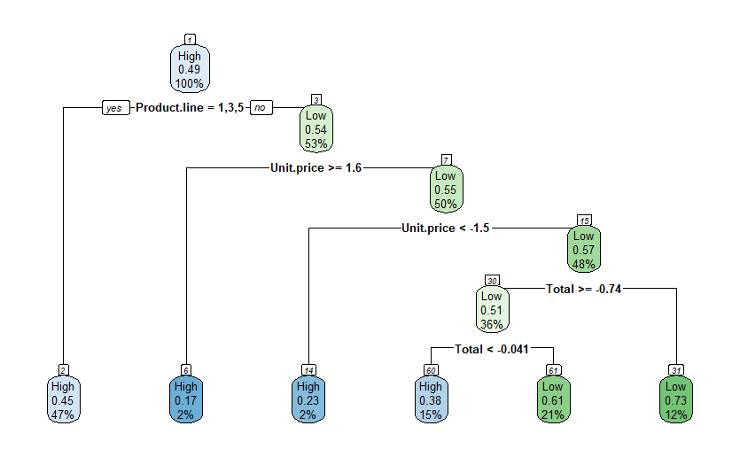

```r
rpart.plot(rpart_model, box.palette = "auto", nn = TRUE)
```

repeat the step but with Information Gain

```r
features <- dataset[, c("City", "Customer.type", "Gender", "Product.line", "Unit.price", "Quantity", "Total", "Payment")]
target <- (dataset$Rating)
```

partition method (60% for training)

```r
set.seed(1234)
splits <- createDataPartition(target, p = 0.6, list = FALSE)
```

Create training and testing sets

```r
train_data <- dataset[splits, ]
test_data <- dataset[-splits, ]
```

Train a decision tree with Information Gain

```r
model <- train(
  x = train_data[, c("City", "Customer.type", "Gender", "Product.line", "Unit.price", "Quantity", "Total", "Payment", "Date", "Time","gross.income", "cogs")],
  y = train_data$Rating,
  method = "rpart",
  parms = list(split = "information"),
  trControl = trainControl(method = "cv", number = 3)
)
```

We make predictions on the test set

```r
predictions <- predict(model, newdata = test_data)
```

We start to evaluate the method

```r
predictions<- factor(predictions)
test_data$Rating <- factor(test_data$Rating)
confusion_matrix <- confusionMatrix(predictions, test_data$Rating)
print(confusion_matrix)
```

```
Confusion Matrix and Statistics

          Reference
Prediction High Low
      High  178 173
      Low     0   0

               Accuracy : 0.5071
                 95% CI : (0.4535, 0.5606)
    No Information Rate : 0.5071
    P-Value [Acc > NIR] : 0.5214

                  Kappa : 0

 Mcnemar's Test P-Value : <2e-16

            Sensitivity : 1.0000
            Specificity : 0.0000
         Pos Pred Value : 0.5071
         Neg Pred Value :    NaN
             Prevalence : 0.5071
         Detection Rate : 0.5071
   Detection Prevalence : 1.0000
      Balanced Accuracy : 0.5000

       'Positive' Class : High
```

We Assuming model is the final model

```r
rpart_model <- model$finalModel
```

Then we print the decision tree

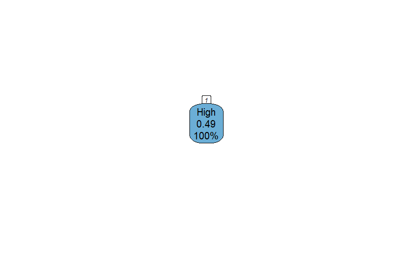

```r
rpart.plot(rpart_model, box.palette = "auto", nn = TRUE)
```

repeat the step but with Gain Ratio

```r
features <- dataset[, c("City", "Customer.type", "Gender", "Product.line", "Unit.price", "Quantity", "Total", "Payment")]
target <- (dataset$Rating)
```

partition method (60% for training)

```r
set.seed(1234)
splits <- createDataPartition(target, p = 0.6, list = FALSE)
```

Create training and testing sets

```r
train_data <- dataset[splits, ]
test_data <- dataset[-splits, ]
```

Train a decision tree with Gain Ratio

```r
model <- train(
  x = train_data[, c("City", "Customer.type", "Gender", "Product.line", "Unit.price", "Quantity", "Total", "Payment", "Date", "Time","gross.income", "cogs")],
  y = train_data$Rating,
  method = "rpart",
  parms = list(split = "gain_ratio"),
  trControl = trainControl(method = "cv", number = 3)
)
```

We make predictions on the testset

```r
predictions <- predict(model, newdata = test_data)
```

We start to evaluate the method

```r
predictions<- factor(predictions)
test_data$Rating <- factor(test_data$Rating)
confusion_matrix <- confusionMatrix(predictions, test_data$Rating)
print(confusion_matrix)
```

```
Confusion Matrix and Statistics

          Reference
Prediction High Low
      High  178 173
      Low     0   0

               Accuracy : 0.5071
                 95% CI : (0.4535, 0.5606)
    No Information Rate : 0.5071
    P-Value [Acc > NIR] : 0.5214

                  Kappa : 0

 Mcnemar's Test P-Value : <2e-16

            Sensitivity : 1.0000
            Specificity : 0.0000
         Pos Pred Value : 0.5071
         Neg Pred Value :    NaN
             Prevalence : 0.5071
         Detection Rate : 0.5071
   Detection Prevalence : 1.0000
      Balanced Accuracy : 0.5000

       'Positive' Class : High
```

We Assuming model is the final model

```r
rpart_model <- model$finalModel
```

Then we print the decision tree

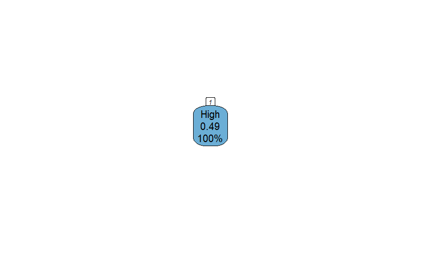

```r
rpart.plot(rpart_model, box.palette = "auto", nn = TRUE)
```